### Log in to the Server:

1. Throughout the live contest, we are going to use the server (neural.pstat.ucsb.edu) to update your prediction on the ERP of the S&P500 and trading strategy about how much to buy or sell. First of all, check your inbox and search for “ERP Contest - Username and Password to Connect to the Server” like this:

[figure not shown]

2. Download the attached file [`Connecting to server via SSH.pdf`](https://ucsb-erp-contest.herokuapp.com/static/Connecting%20to%20server%20via%20SSH.pdf) and follow instructions. You might need an application for the SSH (Secure Shell) protocol such as `Terminal` on Mac and `PuTTY` on Windows. Your login information are also attached to the email. Open the Google Doc [`2020_teams_login`](https://docs.google.com/spreadsheets/d/19VhXh7IPp8fQi_pP8JOcS1LhBBg6wd-iTMScodtzp2k/edit#gid=0) and check for your Username and Password.
3. Start your application. Here, I use `PuTTY` on Windows. Write down the server name `neural.pstat.ucsb.edu`.

[figure not shown]

4. Log in using your Username and Password. If you are successfully logged in then you will see like this:

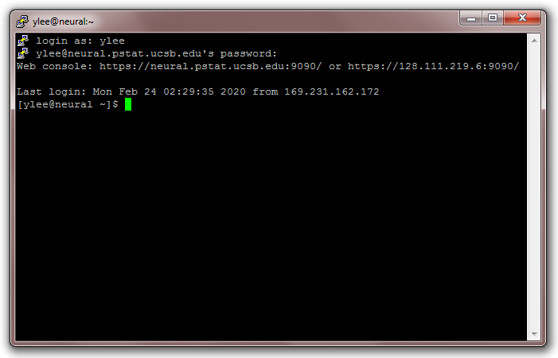

### Upload your Files to the Server:

1. During the live contest, you have to update your prediction and trading strategy every (trading) day. To do this, you need the following 5-6 files:
   - Your code: R, python, etc. It takes `ucsbdata.csv` and returns `output.txt`. ex) `demo_server.R`
   - A shell executable file: a file that excutes your code. ex) `runner.sh` (in this file it consists of one command line `Rscript demo_server.R`)
   - A data file [`ucsbdata.csv`](https://ucsb-erp-contest.herokuapp.com/static/ucsbdata.csv).
   - Your data file if you develop new variables (optional). ex) `your_data.csv`
   - `checker.py`: a program that will check your output.
   - `checker.sh`: a file that will excute `checker.py`.
2. Go to our [webpage](https://ucsb-erp-contest.herokuapp.com) and download [`checker.zip`](https://ucsb-erp-contest.herokuapp.com/static/checker.zip). You will find `checker.py` and `checker.sh` in it.

[figure not shown]

3. Select the Data tab on our webpace and download the data file [`ucsbdata.csv`](https://ucsb-erp-contest.herokuapp.com/static/ucsbdata.csv). For my convenience, I rename it as `ucsbdata_demo.csv`.

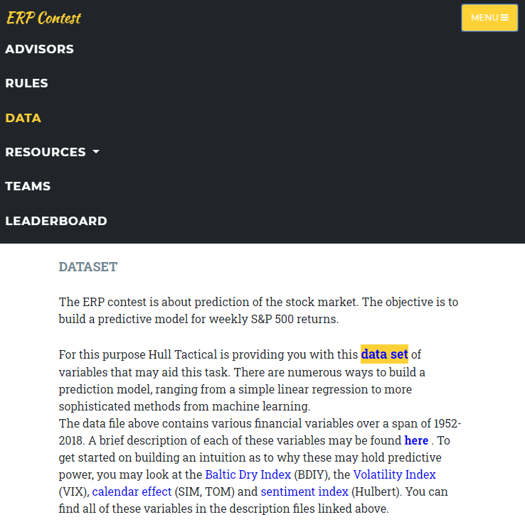

4. Create shell executable file. For example, to run my R code `demo_server.R`, I open an editor program like `NotePad` and write down `Rscript demo_server.R` and save it as a `.sh` format.

[figure not shown]

5. Prepare your own data file if needed (optional).
6. Put these files together in one directory.

[figure not shown]

7. Run `cmd` and go to the directory where the files are stored. My address is `C:\ERP` so I use `cd C:\ERP`.

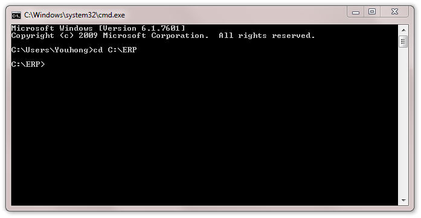

8. Copy these file to the server by executing the following two commands: `path C:\Program Files\PuTTY` and `pscp -r * ylee@neural.pstat.ucsb.edu:/home/ylee`. You should replace `C:\Program Files\PuTTY` by the address where `PuTTY` is installed on your computer and `ylee` by your Username. Don’t forget to insert your Password.

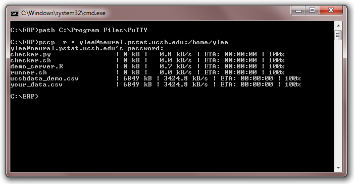

9. Going back to `PuTTY`, check that all the files are uploaded in your home directory by using `ls`.

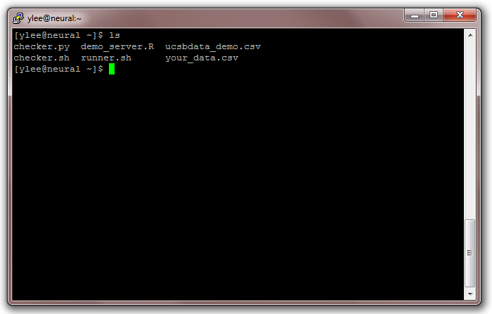

### Run your Code on the Server:

1. Now, you are ready to run your program. Execute your `.sh` file by typing `sh runner.sh`. Make sure that an output file `output.txt` is created.

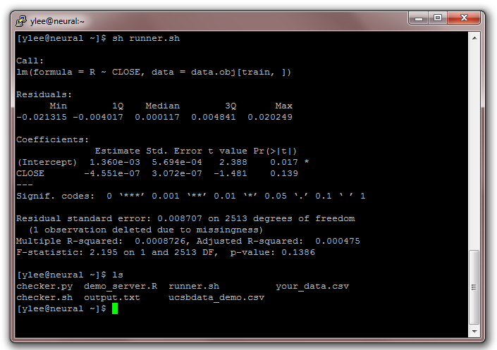

2. Before running a checker program, you may print `output.txt` and see what’s inside by using `cat output.txt`. Three numbers should be (1) a predicted ERP of the S&P500, (2) the amount of the S&P500 index fund to buy, and (3) the amount to sell in order.

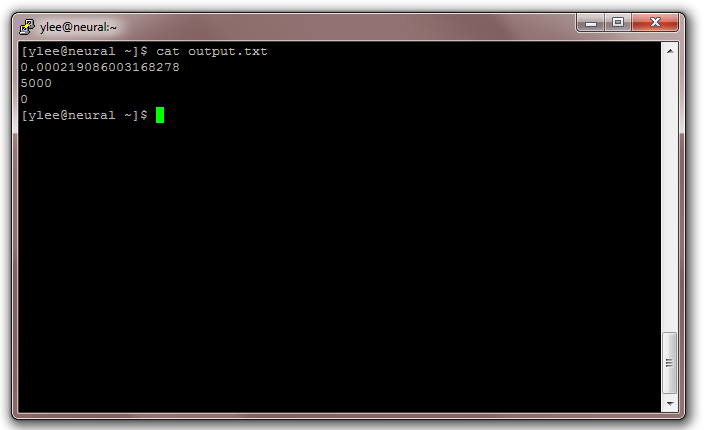

3. Finally, excute `checker.sh` to confirm that your output file `output.txt` is correct by using `sh checker.sh`.

[figure not shown]